# Bay Wheels - An Alternative for Public Transportation

## by Carlos Carcamo

## Investigation Overview

Bay Wheels is a regional public bicycle sharing system in the San Francisco Bay Area, California. Is Bay Wheels a real solution? Are people using it for get to work or leisure purposes? Let's see some data that will give a good point to Bay Wheels. In this presentation we will see the realition beetween Trips, Trips Duration, Hours and Day of Week where the Bay Wheels service is used to get people from their homes to their office

## Dataset Overview

The dataset used for this Investigation consists of data from January 2019 to December 2019. More than 2 Million of trips were gathered to get this insights. The file contains data about Trip Duration, Start and End datetime for each each trip and the Station involve in the trip

## Long or Short bike trips?

Let's start digging into the data. And try to discover how the trip durations are distributed. The trip duration seems to be distributed between 100 and 3000 seconds, having the strongest distribution between 300 and 1000 seconds (around 5 and 17 minutes). The mean time duration is 667 seconds (11.11 minutes). So this is leading us to the idea that peope preferd short trips. So, are people using it for get to work or leisure purposes?

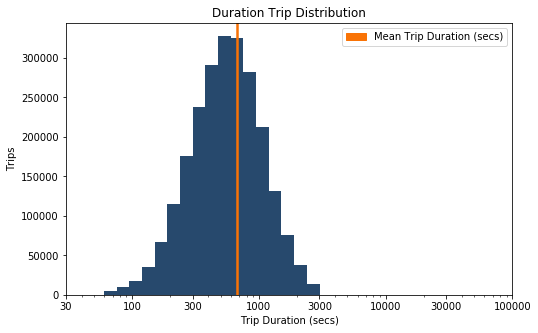

```python
#Import lib to customize legend
import matplotlib.patches as mpatches

#Get mean duration again
mean_duration = df.duration_sec.mean()

#Define bins for log scale
bin_edges = 10 ** np.arange(np.log10(df.duration_sec.min()), np.log10(df.duration_sec.max()) + 0.1, 0.1)

#Define ticks to show on chart
ticks = [30,100,300,1000,3000,10000,30000,100000]

#Plot the chart
plt.figure(figsize=[8, 5]);
plt.hist(data = df, x ='duration_sec', bins = bin_edges, color='#27496d');
plt.xscale("log");
plt.xticks(ticks,ticks);
plt.axvline(mean_duration, color = '#f97306', lw=2.5);
plt.title('Duration Trip Distribution')
plt.xlabel('Trip Duration (secs)');
plt.ylabel('Trips');
legend = mpatches.Patch(color='#f97306', label='Mean Trip Duration (secs)')
plt.legend(handles=[legend]);
```

## When is the best time to ride a bike?

Now, let's see in which days Bay Wheels have the highest demand of service. The following heat map shows us that weekdays have more activity than weekends. We can see 2 rush hours for the service in the weekdays, the fisrt one between 7 and 9 am. and the second one between 4 and 6 pm. This can be interpretated as people use the service to move from their homes to office in the morning (between 7 and 9 am) and from their offices to ther homes in the afternoom (between 4 and 6 pm), as the highest demand for the service occurs at the begining and at the end of the work journal.

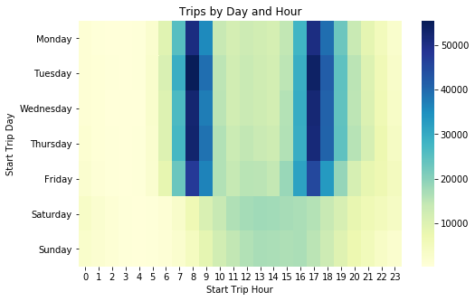

```python
#Get trip by Day and Hour
ct_counts = df.groupby(['start_time_dayofweek', 'start_time_hour']).size()
ct_counts = ct_counts.reset_index(name='count')
ct_counts = ct_counts.pivot(index = 'start_time_dayofweek', columns = 'start_time_hour', values = 'count')

#Plot the chart
plt.figure(figsize=[8, 5]);

sb.heatmap(ct_counts, cmap='YlGnBu');
plt.title('Trips by Day and Hour')
plt.xlabel('Start Trip Hour');
plt.ylabel('Start Trip Day');
```

## How long is a trip by day and hour?

Let's to reinforce the idea of San Franciscans use Bay Wheels as a transportation for their works. This chart shows mean duration os trips per day per hour. The longer trips are rode on weekends, when people don't have a deadline hour to be present at the office. Also, something really intersting appeared at 8am for weekdays, the mean duration seems to be the same as the mean duration for the entire dataset, around 670secs. This can lead to say than people tend to go to work between 8 and 9 am.

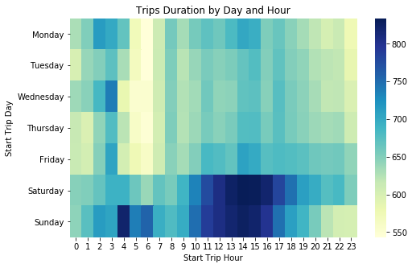

```python
#Get trip duration mean by day and hour
ct_counts = df.groupby(['start_time_dayofweek', 'start_time_hour'])['duration_sec'].mean()
ct_counts = ct_counts.reset_index(name='mean')
ct_counts = ct_counts.pivot(index = 'start_time_dayofweek', columns = 'start_time_hour', values = 'mean')

#Plot the chart
plt.figure(figsize=[8, 5]);
sb.heatmap(ct_counts, cmap='YlGnBu');
plt.title('Trips Duration by Day and Hour')
plt.xlabel('Start Trip Hour');
plt.ylabel('Start Trip Day');
```

## Trips by time for 2019

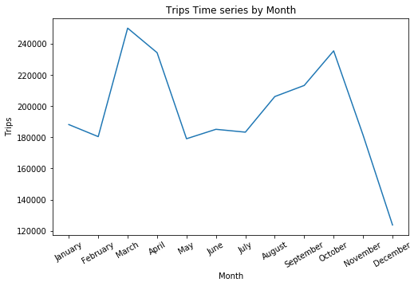

```python
#Get total trips per month
df_months = df.groupby('start_time_month_name')['trips'].sum()
#Plot the chart
plt.figure(figsize=[8, 5]);
plt.plot(df_months.index, df_months);
plt.xticks(rotation=30);
plt.title('Trips Time series by Month')
plt.xlabel('Month');
plt.ylabel('Trips');
```